# Structural Topic Models: A Short Tutorial

Text as Data, CEU

An LDA model represents each speech as a mixture of topics. A structural topic model (STM) can also use document metadata to model how topic prevalence varies. Here we ask how attention to war and international conflict in State of the Union speeches varies over time, while accounting for the president’s party.

## Setup

Install the `stm` and `rmarkdown` packages if needed.

```r
library(stm)
set.seed(2026)
speeches <- read.csv("sotu.csv", stringsAsFactors = FALSE)
speeches <- subset(speeches, year >= 1901 & !is.na(text) & nzchar(text) &
                     party %in% c("Democratic", "Republican"))
speeches$party <- factor(speeches$party, levels = c("Democratic", "Republican"))
speeches$year <- as.numeric(speeches$year)
head(speeches[, c("president", "year", "party")])
```

```
##              president year      party
## 113 Theodore Roosevelt 1901 Republican
## 114 Theodore Roosevelt 1902 Republican
## 115 Theodore Roosevelt 1903 Republican
## 116 Theodore Roosevelt 1904 Republican
## 117 Theodore Roosevelt 1905 Republican
## 118 Theodore Roosevelt 1906 Republican
```

```r
table(speeches$party)
```

```
##
## Democratic Republican
##         61         67
```

Each document is a speech. The party is the president’s party, and observations over time are not independent political experiments. The corpus, preprocessing choices, and document length all affect the results.

## Prepare the documents

`textProcessor` tokenizes, removes common English stopwords and stems words. `prepDocuments` removes rare terms and empty documents. Use the returned metadata, which stays aligned with the retained documents.

```r
processed <- textProcessor(documents = speeches$text, metadata = speeches,
                           lowercase = TRUE, removestopwords = TRUE,
                           removenumbers = TRUE, removepunctuation = TRUE,
                           stem = TRUE, verbose = FALSE)
prepared <- prepDocuments(processed$documents, processed$vocab,
                          processed$meta, lower.thresh = 4, verbose = FALSE)
documents <- prepared$documents
vocab <- prepared$vocab
meta <- prepared$meta
cat("Retained speeches:", length(documents), "\nVocabulary size:", length(vocab), "\n")
```

```
## Retained speeches: 128
## Vocabulary size: 4806
```

## Fit an STM

We set the number of topics to 10. The prevalence formula lets the expected topic proportions vary with party and a smooth function of year. The model estimates topics and their prevalence jointly. We do not include a content covariate, so the word distribution for a topic is shared across these groups.

```r
model <- stm(documents = documents, vocab = vocab, K = 10,
             prevalence = ~ party + s(year), data = meta,
             init.type = "Spectral", max.em.its = 75, verbose = FALSE)
```

## Interpret topics

Look at both frequent and distinctive words. Then read representative speeches rather than naming a topic from a word list alone.

```r
labelTopics(model, n = 8)
```

```
## Topic 1 Top Words:
##       Highest Prob: will, nation, year, govern, program, must, state, dollar
##       FREX: dollar, fiscal, expenditur, price, program, farm, billion, estim
##       Lift: two-year, electrif, servicemen, seaway, export-import, redevelop, hydroelectr, labor-manag
##       Score: two-year, expenditur, communist, atom, shall, wartim, liquid, program
## Topic 2 Top Words:
##       Highest Prob: govern, state, unit, will, depart, congress, year, law
##       FREX: canal, panama, appoint, statut, arbitr, court, depart, tariff
##       Lift: undon, argentin, liberia, postmast, civil-servic, magazin, valorem, light-hous
##       Score: isthmus, undon, arbitr, post-offic, hagu, postmast, canal, battleship
## Topic 3 Top Words:
##       Highest Prob: will, american, america, year, peopl, nation, countri, must
##       FREX: applaus, iraq, terrorist, iraqi, terror, thank, regim, afghanistan
##       Lift: applaus, cheney, ryan, faith-bas, hussein, iraqi, lone, saddam
##       Score: applaus, terrorist, tonight, iraq, iraqi, weve, qaida, afghanistan
## Topic 4 Top Words:
##       Highest Prob: nation, world, will, war, must, peopl, peac, can
##       FREX: communist, soviet, victori, free, europ, aggress, fight, war
##       Lift: axi, nazi, tank, appeas, sabotag, rome, rumor, stalin
##       Score: axi, soviet, communist, nazi, atom, conquest, japanes, tank
## Topic 5 Top Words:
##       Highest Prob: will, year, program, nation, congress, feder, develop, administr
##       FREX: energi, oil, implement, signific, regulatori, administr, ensur, environment
##       Lift: bilater, ceta, judgeship, reactor, shelf, cabinet-level, housejanuari, decontrol
##       Score: nuclear, shelf, environment, soviet, solar, sector, regulatori, ensur
## Topic 6 Top Words:
##       Highest Prob: nation, law, will, govern, state, can, great, upon
##       FREX: man, forest, corpor, interst, island, supervis, exercis, mere
##       Lift: notori, wage-work, fellow-citizen, tiller, upright, marksmanship, wrongdo, standpoint
##       Score: wage-work, notori, exposit, injunct, hagu, wrongdo, peculiar, isthmus
## Topic 7 Top Words:
##       Highest Prob: will, year, american, work, peopl, america, can, new
##       FREX: that, dont, cant, parent, weve, get, colleg, ive
##       Lift: anymor, apprenticeship, bailout, biden, bosnia, bradi, ceo, cyber
##       Score: that, tonight, weve, gore, dont, kid, theyr, ive
## Topic 8 Top Words:
##       Highest Prob: govern, will, nation, congress, countri, year, can, public
##       FREX: agricultur, relief, bank, debt, board, reduct, per, depress
##       Lift: float, shoal, nitrat, deflat, muscl, tile, etc, reproduct
##       Score: float, tile, nitrat, shoal, muscl, expenditur, reclam, valuat
## Topic 9 Top Words:
##       Highest Prob: will, nation, govern, must, upon, peopl, great, world
##       FREX: thought, affair, matter, seem, manifest, definit, immedi, counsel
##       Lift: sinist, foodstuff, programm, unmind, intrigu, unselfish, magnifi, enthusiast
##       Score: sinist, programm, shall, cruiser, manifest, battleship, earnest, porto
## Topic 10 Top Words:
##       Highest Prob: will, year, nation, can, american, new, must, america
##       FREX: vietnam, percent, growth, spend, inflat, crime, billion, goal
##       Lift: salt, rayburn, flower, seventi, realism, sam, jobless, invulner
##       Score: salt, tonight, vietnam, nuclear, soviet, goal, weve, percent
```

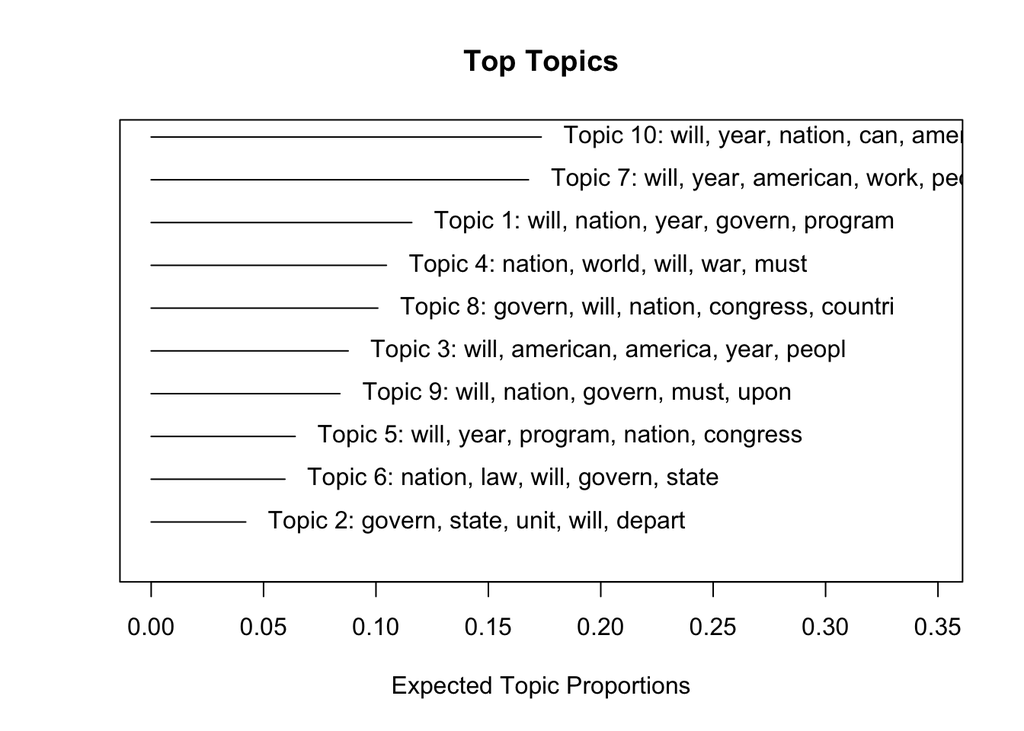

```r
plot(model, type = "summary", n = 5)
```

```r
# In this fitted model, topic 4 contains war, Soviet, victory, and peace terms.
# Topic numbers can change across models. Check labelTopics before using this number.
topic_id <- 4
examples <- findThoughts(model, texts = meta$text, topics = topic_id, n = 3)
top_rows <- order(model$theta[, topic_id], decreasing = TRUE)[1:3]
data.frame(meta[top_rows, c("president", "year", "party")],
           topic_proportion = round(model$theta[top_rows, topic_id], 3))
```

```
##                president year      party topic_proportion
## 45 Franklin D. Roosevelt 1945 Democratic            0.998
## 51        Harry S Truman 1951 Democratic            0.997
## 42 Franklin D. Roosevelt 1943 Democratic            0.997
```

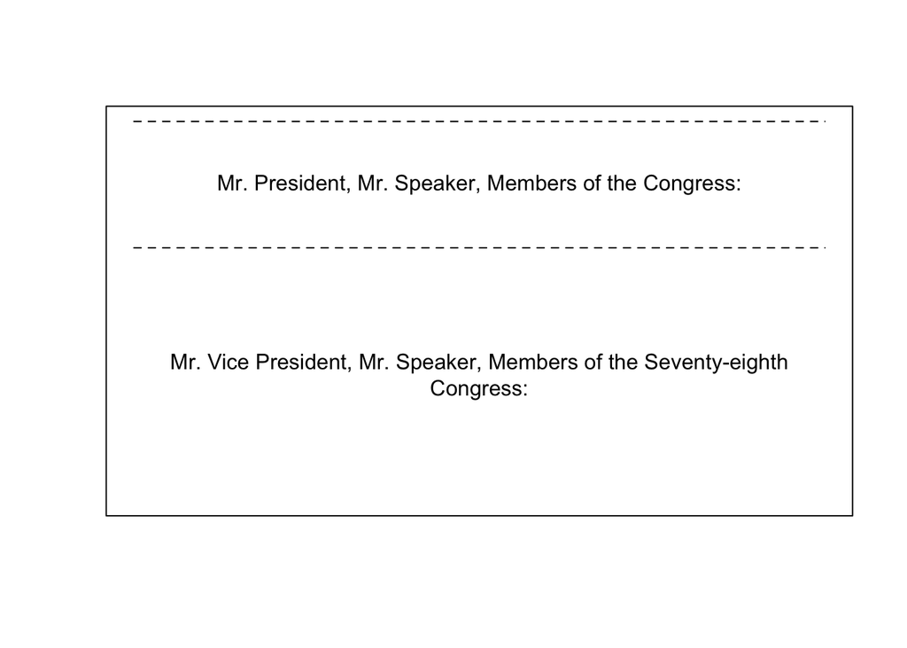

```r
plotQuote(examples$docs[[1]], width = 70, maxwidth = 350)
```

Topic numbers are arbitrary. Interpret a topic by examining its words and speeches, and check whether it remains recognizable under reasonable choices of preprocessing and topic number.

## How does the topic vary over time?

The following estimates topic proportions as a function of party and year, propagating uncertainty from the fitted topic model. The curve displays the modelled association with year.

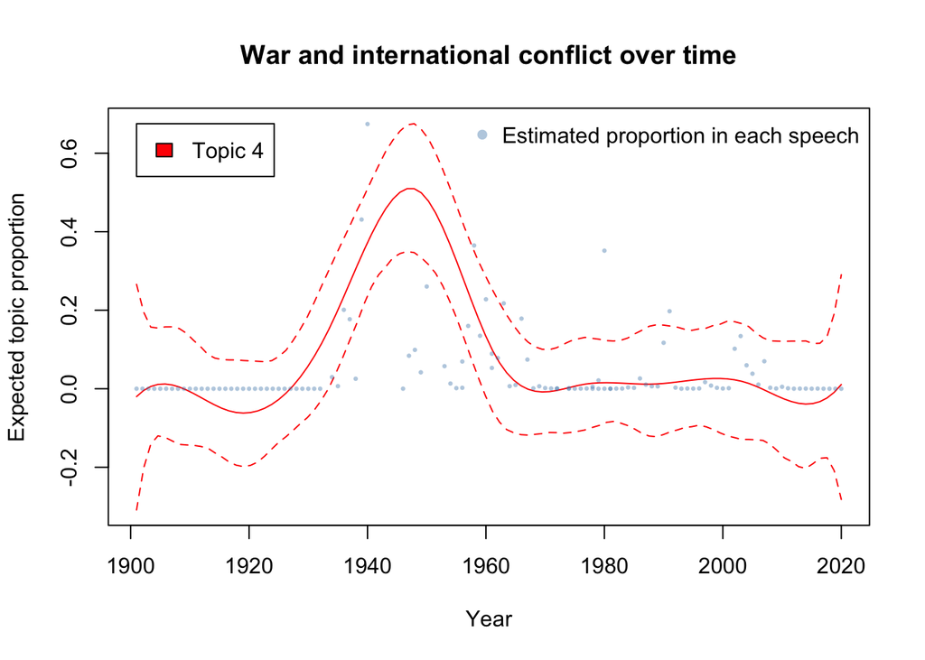

```r
effects <- estimateEffect(1:10 ~ party + s(year), model, metadata = meta,
                          uncertainty = "Global")
plot(effects, covariate = "year", topics = topic_id, model = model,
     method = "continuous", xlab = "Year",
     ylab = "Expected topic proportion",
     main = "War and international conflict over time")
points(meta$year, model$theta[, topic_id], pch = 16, cex = 0.45,
       col = adjustcolor("steelblue", alpha.f = 0.4))
legend("topright", legend = "Estimated proportion in each speech",
       pch = 16, col = adjustcolor("steelblue", alpha.f = 0.4), bty = "n")
```

## Compare parties across all topics

```r
summary(effects, topics = 1:10)
```

```
##
## Call:
## estimateEffect(formula = 1:10 ~ party + s(year), stmobj = model,
##     metadata = meta, uncertainty = "Global")
##
##
## Topic 1:
##
## Coefficients:
##                 Estimate Std. Error t value Pr(>|t|)
## (Intercept)     -0.07312    0.13988  -0.523 0.602154
## partyRepublican  0.08768    0.04803   1.826 0.070460 .
## s(year)1        -0.07972    0.25045  -0.318 0.750819
## s(year)2         0.19225    0.18740   1.026 0.307087
## s(year)3        -0.19831    0.21619  -0.917 0.360907
## s(year)4         0.72780    0.19941   3.650 0.000395 ***
## s(year)5         0.39637    0.19727   2.009 0.046832 *
## s(year)6        -0.09607    0.17173  -0.559 0.576926
## s(year)7         0.13797    0.18337   0.752 0.453344
## s(year)8        -0.06034    0.20552  -0.294 0.769591
## s(year)9         0.11929    0.21456   0.556 0.579313
## s(year)10       -0.03033    0.18542  -0.164 0.870331
## ---
## Signif. codes:  0 '***' 0.001 '**' 0.01 '*' 0.05 '.' 0.1 ' ' 1
##
##
## Topic 2:
##
## Coefficients:
##                 Estimate Std. Error t value Pr(>|t|)
## (Intercept)     -0.13749    0.14010  -0.981    0.328
## partyRepublican  0.03116    0.03009   1.036    0.303
## s(year)1         1.03038    0.23616   4.363  2.8e-05 ***
## s(year)2        -0.04923    0.17295  -0.285    0.776
## s(year)3         0.16144    0.18035   0.895    0.373
## s(year)4         0.13376    0.16205   0.825    0.411
## s(year)5         0.13557    0.15431   0.879    0.381
## s(year)6         0.14316    0.15650   0.915    0.362
## s(year)7         0.10460    0.16463   0.635    0.526
## s(year)8         0.12598    0.18069   0.697    0.487
```

[output cut: 149 more lines]

```
##                  Estimate Std. Error t value Pr(>|t|)
## (Intercept)     -0.036321   0.140596  -0.258 0.796606
## partyRepublican -0.006942   0.042644  -0.163 0.870971
## s(year)1         0.174473   0.248693   0.702 0.484358
## s(year)2        -0.197271   0.175642  -1.123 0.263697
## s(year)3         0.352704   0.204062   1.728 0.086574 .
## s(year)4        -0.312460   0.178646  -1.749 0.082928 .
## s(year)5         0.745443   0.189858   3.926 0.000147 ***
## s(year)6         0.606278   0.203316   2.982 0.003491 **
## s(year)7         0.260265   0.214597   1.213 0.227666
## s(year)8        -0.090854   0.224314  -0.405 0.686202
## s(year)9         0.098454   0.217774   0.452 0.652047
## s(year)10        0.024604   0.184715   0.133 0.894265
## ---
## Signif. codes:  0 '***' 0.001 '**' 0.01 '*' 0.05 '.' 0.1 ' ' 1
```

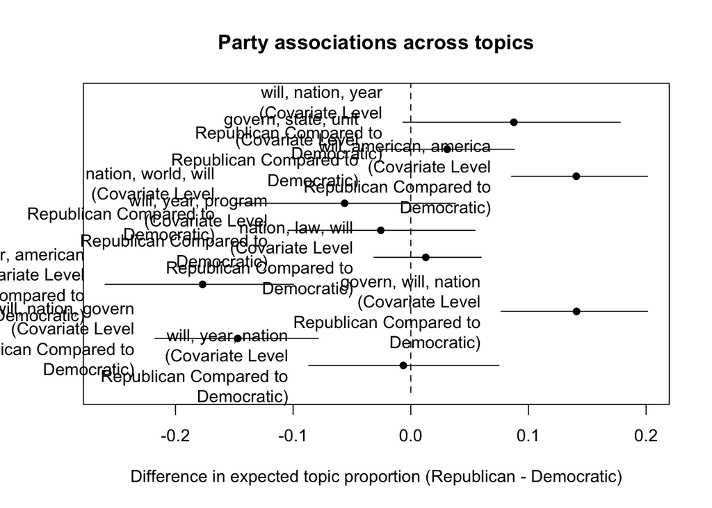

```r
plot(effects, covariate = "party", topics = 1:10, model = model,
     method = "difference", cov.value1 = "Republican", cov.value2 = "Democratic",
     xlab = "Difference in expected topic proportion (Republican - Democratic)",
     main = "Party associations across topics",
     labeltype = "prob", n = 3)
```

## Different words within a topic

The prevalence model asks whether a topic is more common in one group. A **content covariate** asks whether the words associated with the same topic vary across groups.

```r
set.seed(2026)
content_data <- prepDocuments(documents, vocab, meta, lower.thresh = 20,
                              verbose = FALSE)
content_meta <- content_data$meta
content_model <- stm(documents = content_data$documents, vocab = content_data$vocab, K = 6,
                     prevalence = ~ party + s(year), content = ~ party,
                     data = content_meta, init.type = "Spectral",
                     max.em.its = 25, verbose = FALSE)
labelTopics(content_model, n = 8)
```

```
## Topic Words:
##  Topic 1: compass, frustrat, adversari, latin, despair, kennedi, distinguish, spoke
##  Topic 2: peculiar, sympathi, utter, island, railway, superior, render, alik
##  Topic 3: terrorist, that, theyr, laughter, your, cant, iraq, wont
##  Topic 4: estim, exclud, receipt, cent, furnish, contract, warrant, compos
##  Topic 5: minor, consolid, signific, urban, handicap, coordin, disabl, rural
##  Topic 6: atom, communist, spiritu, bargain, armament, communism, output, uniti
##
##  Covariate Words:
##  Group Democratic: master, think, isol, combat, sick, seek, north, india
##  Group Republican: menac, gradual, list, columbia, park, primarili, rang, branch
##
##  Topic-Covariate Interactions:
##  Topic 1, Group Democratic: beauti, eastern, gold, color, poverti, penalti, vietnam, south
##  Topic 1, Group Republican: doesnt, there, guest, peacetim, dont, truli, veto, yes
##
##  Topic 2, Group Democratic: plane, manifest, alter, await, british, argument, german, privileg
##  Topic 2, Group Republican: supervis, corpor, interst, indian, forest, unwis, compos, ampl
##
##  Topic 3, Group Democratic: embrac, everybodi, argument, doesnt, town, gas, gun, reward
##  Topic 3, Group Republican: bomb, terror, compass, brave, mandat, regim, ladi, choic
##
##  Topic 4, Group Democratic: tendenc, drastic, dollar, peacetim, anticip, long-rang, fiscal, bargain
##  Topic 4, Group Republican: deposit, canal, sympathi, railway, supervis, waterway, mississippi, court
##
##  Topic 5, Group Democratic: ratif, afghanistan, implement, southern, strateg, coal, gulf, regulatori
##  Topic 5, Group Republican: bomb, output, pollut, manpow, career, recreat, cancer, eight
##
##  Topic 6, Group Democratic: privileg, eight, storm, sister, profess, specul, endang, recoveri
##  Topic 6, Group Republican: peacetim, membership, continent, aircraft, weapon, warfar, missil, partnership
##
```

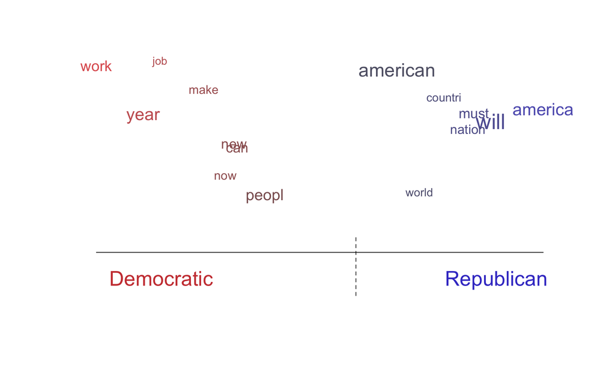

```r
content_topic <- 3
plot(content_model, type = "perspectives", topics = content_topic,
     covarlevels = c("Democratic", "Republican"),
     plabels = c("Democratic", "Republican"), n = 25)
```

```r
for (group in levels(content_meta$party)) {
  rows <- which(content_meta$party == group)
  top <- rows[order(content_model$theta[rows, content_topic], decreasing = TRUE)[1:2]]
  cat("\n", group, "\n")
  print(data.frame(content_meta[top, c("president", "year")],
                   topic_proportion = round(content_model$theta[top, content_topic], 3)))
  for (i in top) {
    cat(substr(gsub("[[:space:]]+", " ", content_meta$text[i]), 1, 400), "...\n\n")
  }
}
```

```
##
##  Democratic
##        president year topic_proportion
## 123 Barack Obama 2015                1
## 122 Barack Obama 2014                1
## The President. Mr. Speaker, Mr. Vice President, Members of Congress, my fellow Americans: We are 15 years into this new century. Fifteen years that dawned with terror touching our shores, that unfolded with a new generation fighting two long and costly wars, that saw a vicious recession spread ac…
##
## The President. Mr. Speaker, Mr. Vice President, Members of Congress, my fellow Americans: Today in America, a teacher spent extra time with a student who needed it and did her part to lift America's graduation rate to its highest levels in more than three decades. An entrepreneur flipped on the l…
##
##
##  Republican
##        president year topic_proportion
## 126 Donald Trump 2018                1
## 127 Donald Trump 2019                1
##  The President. Mr. Speaker, Mr. Vice President, Members of Congress, the First Lady of the United States, and my fellow Americans: Less than 1 year has passed since I first stood at this podium, in this majestic Chamber, to speak on behalf of the American people and to address their concerns, th…
##
##  Madam Speaker, Mr. Vice President, Members of Congress, the First Lady of the United States — (applause) — and my fellow Americans: We meet tonight at a moment of unlimited potential. As we begin a new Congress, I stand here ready to work with you to achieve historic breakthroughs for all Americ…
```